# How_to_cluster

# How to: Clustering and Scattering

## Scatter

First, lets create a **basic scatter plot** of the flow data as we see in flowjo. So, set your working directory and load the file

```r
library(dendextend)
setwd("~/Desktop/R work/FlowCore")
read.csv("N Concatflow.csv") -> X
```

This should import the files as a data.frame, in this format we can set our axis as any of the columns in the data. (for flow data like this we may also want to log10 transfor the files)

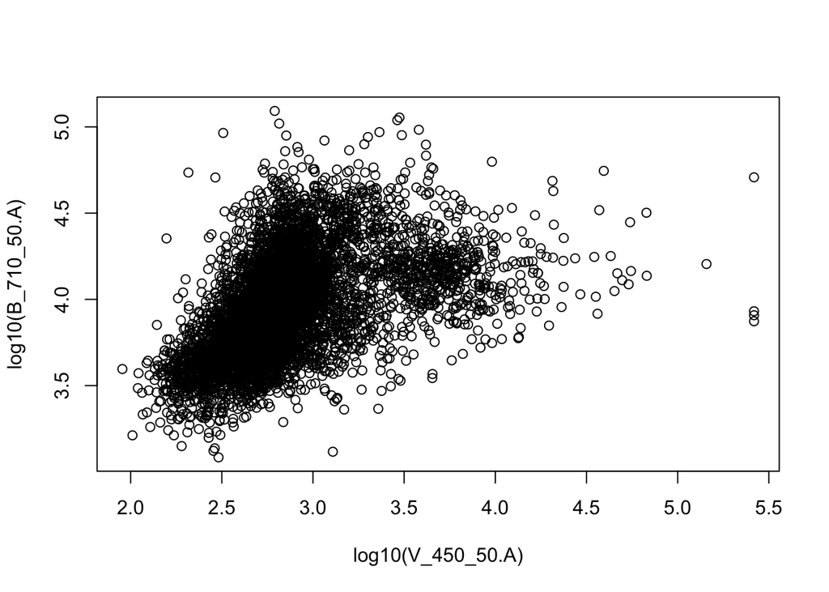

Macrophage CD33 and CD14 expression

```r
plot(log10(B_710_50.A)~log10(V_450_50.A), X)
```

## Now lets **cluster** the same data!

Here i will show you two ways to cluster the same data. The first method, using **euclidian** distance we will display as a cluster tree. The second **kmeans** we will overlay over the original scatter plot.

For both of these methods we will need scale our data first.

```r
apply(X,2,mean) -> m
 apply(X,2,sd) -> s
 scale(X,m,s) -> xs
```

xs is now our scaled data, have a look at it by using head(x) to see a fragment of the top of the data

```r
head(xs)
```

```
##      R_670_14.A  R_780_60.A  V_450_50.A YG_586_15.A YG_780_60.A B_710_50.A
## [1,]  0.2652307  1.28864644 -0.12051830  -0.3742829  -0.2751798  1.5997426
## [2,] -0.2903811 -0.55684975 -0.09882794  -0.5066186  -0.9100809 -0.5210276
## [3,]  0.1688336 -0.02514849 -0.12413335  -0.4306530  -0.8563482  2.0783924
## [4,] -0.5249222 -0.73303532 -0.12521787  -0.6142587  -0.9399324 -0.7802368
## [5,] -0.1894298 -0.62755757 -0.09280284  -0.4942708  -0.9038433 -0.5040654
## [6,] -0.3617302 -0.68308163 -0.13064046  -0.7515604  -0.8999225 -0.8053507
```

### Euclidian clustering (Hierarchical)

The actual clustering itself is easy.  
First we find teh distances between the data points (Euclidean is the default method for this!) The distance here ive named “distance” and the clustered information “hc.c”

```r
dist(xs) -> distance
hclust(distance) -> hc.c
```

Now if we want to see it, just use the following code. (the hang = -1 aligns the bottom of the graph)

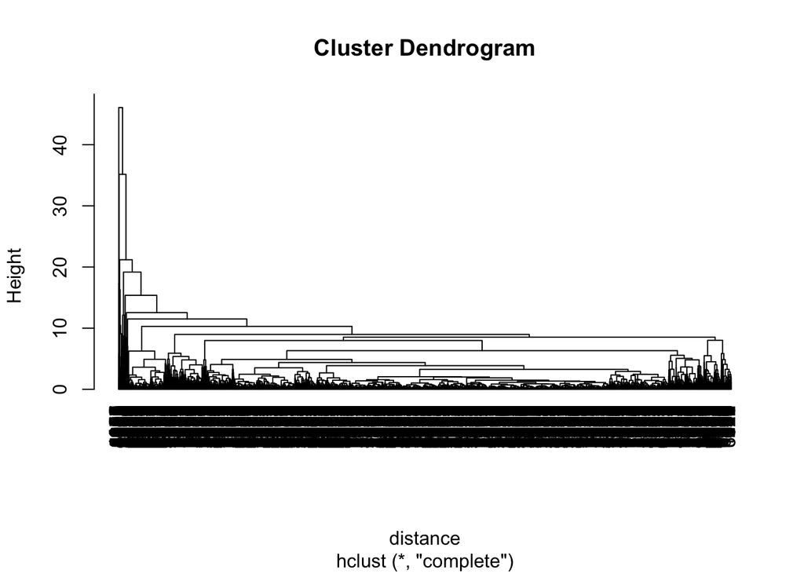

```r
plot(hc.c, hang = -1)
```

### Kmeans Clustering (Non-Hierarchical)

Here we will use the scaled data (xs) from before. We will also tell the algorithm to cut the cluster into 8 subsets. And put the whole thing as “kc”

```r
kmeans(xs, 8) -> kc
```

Now if we want to see the relative expression for each of these markers for each subset, all we do is: (the “$” simply means this feature(column) of Kc)

```r
kc$centers
```

```
##   R_670_14.A  R_780_60.A  V_450_50.A YG_586_15.A YG_780_60.A B_710_50.A
## 1  1.7236915  0.61795130  0.09161387  0.24414496 -0.37441861  2.2965195
## 2 -0.4015000 -0.50520335 -0.10686654 -0.41717208 -0.54555112 -0.5448364
## 3  7.6183740  3.17302874  0.52828906  1.20246435  0.56018130  3.8052541
## 4  0.2820228  0.47147300 -0.04618060 -0.17158880 -0.35102276  0.3486722
## 5 -0.3412703 -0.28695177 -0.08288229 -0.04150766  0.72733001 -0.4010350
## 6  0.2050774 -0.24420783  1.06683147  2.98903355  0.06820922  0.5831521
## 7 -0.4268057  0.07022983 -0.10696340  0.10478033  2.67994710 -0.3253371
## 8  0.9855066  3.79395569 -0.00469043  0.15676402  0.67301772  1.5682382
```

### Scatter plot coloured by kmeans clustering subsets

Here we will combine the basic scatter plot with the kmeans clustering data

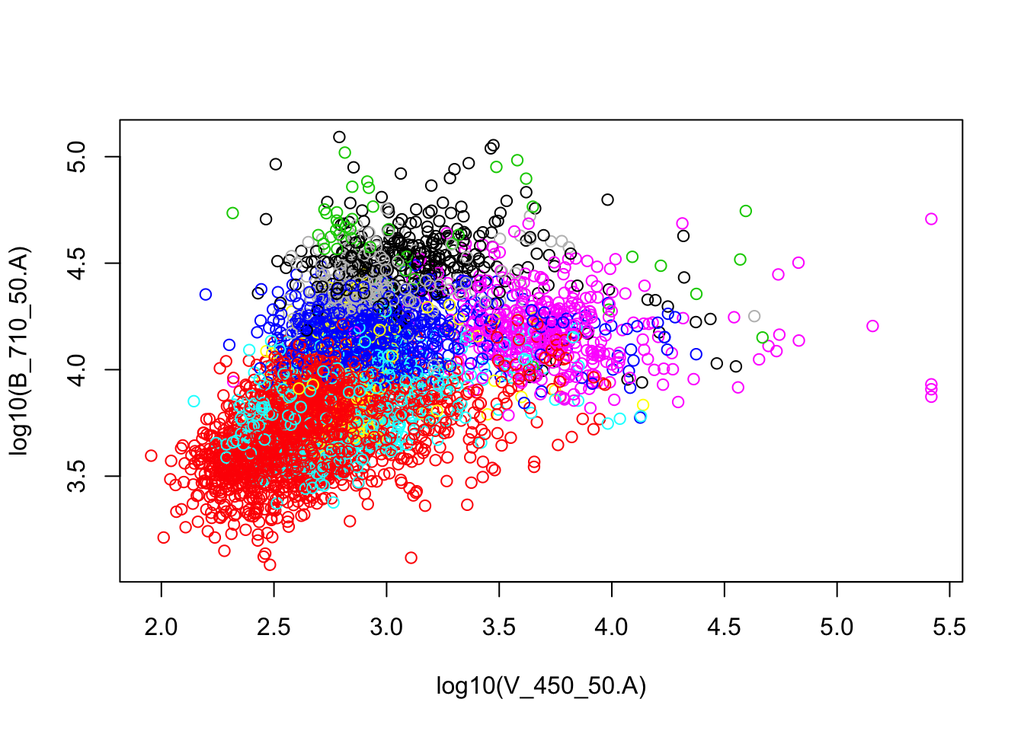

```r
plot(log10(B_710_50.A)~log10(V_450_50.A), X, col = kc$cluster)
```

This will plot the same graph as before, but colour the dots based on the 1-8 clusters. The colours correspond to numbers 1-8 in this order: Black, Red, Green, Blue, Cyan, Magenta, Yellow, Grey.

Using these, we can compare back to the K$centers data to see which cells are where on the scatter plot!